# Problematika predikcie volebných výsledkov

Samuel Hudec

2018

Zostavenie modelu na aspoň kus rozomnú predpoveď volebných výsledkov na základe voľne dostupných dát a vlastného knowhow vyžaduje čas a niekoľko krokov. **Čas je vzácny a preto by som prijal niekoho na pomoc.** V dokumente v skratke zhrniem dôležité a potrebné kroky na podchytenie problematiky na ktoré som natrafil. Niektoré časti budú stále otvorené, nedokončené z rôznych dôvodov.

Na začiatok budeme používať viac zdrojov dát, ten prvý sú prieskumy volebných preferencií zo 4 slovenských agentúr. Takýto prieskum pozostáva z náhodnej vzorky obyvateľstva, ktorých sa pýtajú otázku “Koho by volili keby sa voľby konali dnes”. Druhý zdroj budú určite demografické dáta slovenskej republiky voľne dostupné na stránkach slovenského štatistického úradu. Ostatné zdroje sú otázne.

## Vizualizácia volebných preferencií

Základným kameňom modelu budú samozrejme medzi volebné preferencie. Samotné preferencie nám vedia prezradiť vývoj “spokojnosti” voliča po tom ako sa zloží nová vláda a plní (skôr nie) svoje sľuby.

*Tu potrebujem doplniť dáta ešte dvoch agentúr. Z toho dôvodu si ich nagenerujeme náhodne aby sme mohli pokračovať v načrtnutí problematiky.*

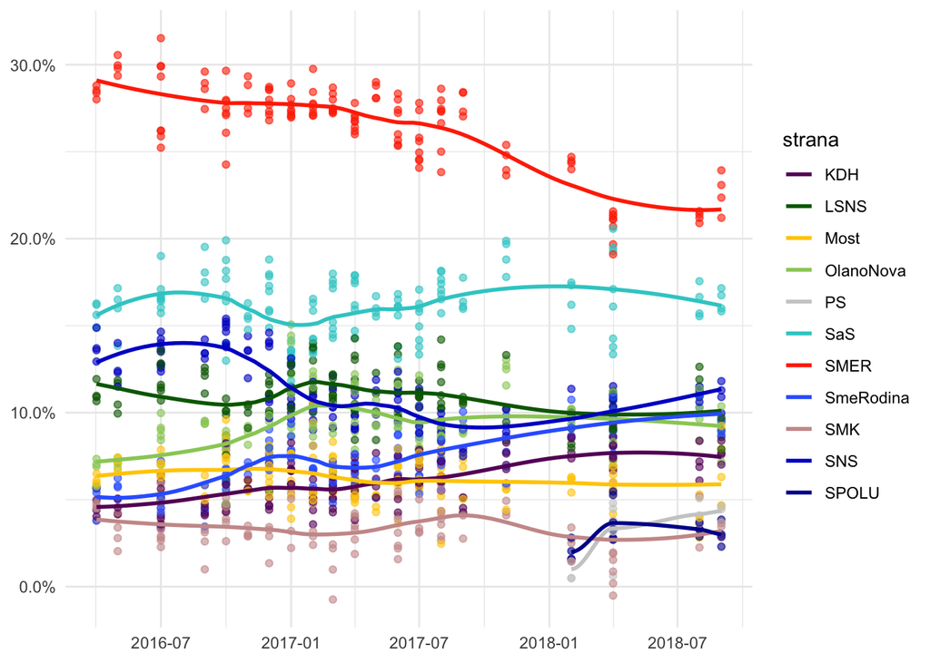

Slovenská scéna sa obohatila o nové volebné strany so slušnými preferenciami. Z hľadiska modelovania nemáme dostatok informácie a budeme musieť chvíľu ešte počkať kým sa dáta nazbierajú.

## Vzájomná korelácia

Ak jedna strana príde o preferencie, môže sa stať, že iná strana preberie voliča alebo volič absolútne stratí chuť voliť. V prvom prípade je vhodné vedieť ako volebné strany spolu závisia, vhodný prvý nástroj môže byť jednoduchá korelácia.

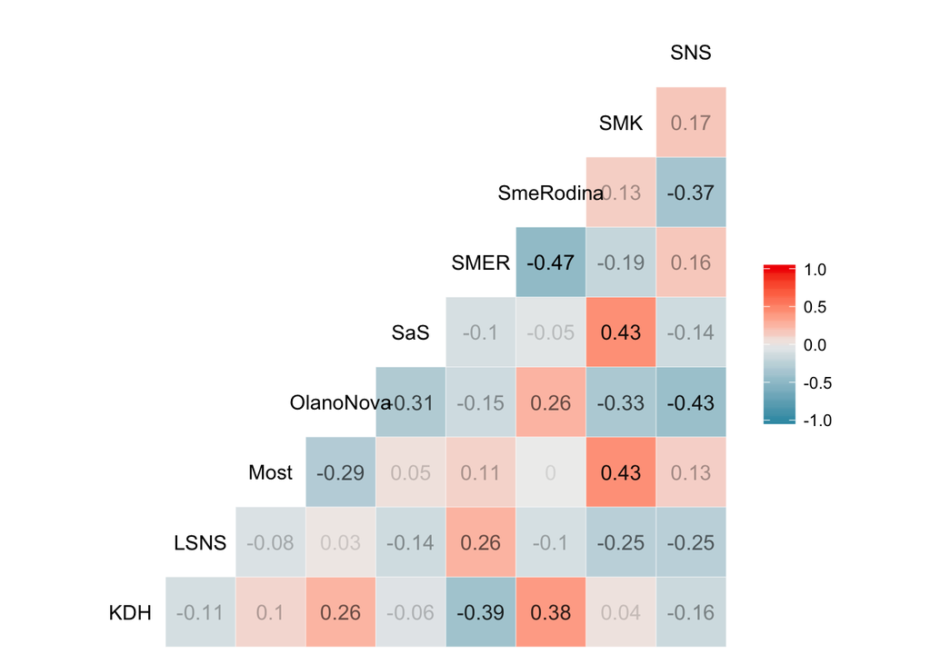

## Viacrozmerny aditívny model

Každú volebnú stranu chceme odmodelovať zvlášť, ale zároveň chceme zachovať a vytiahnuť aj vzájomnú závislosť. Vhodnou prvou voľbou sa nám javí viacrozmerný aditívny model. Na začiatok použijeme defaultné nastavenia funkcie `gam()` z knižnice `mgcv`.

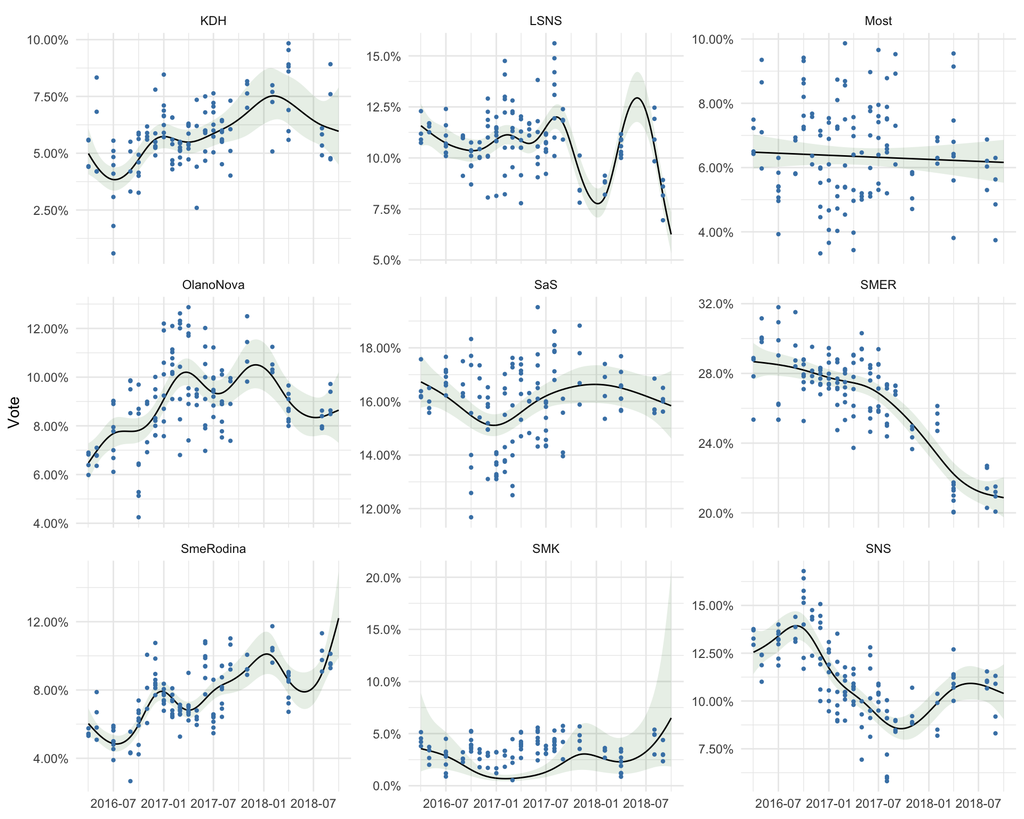

Bodový odhad modelu o jeden časový krok v tomto prípade na Okóber 2018.

| Party | Lower | Midpoint | Upper |
| --- | --- | --- | --- |
| KDH | 4.5 | 6.0 | 7.9 |
| LSNS | 5.3 | 6.3 | 7.3 |
| Most | 5.5 | 6.2 | 6.9 |
| OlanoNova | 7.3 | 8.6 | 10.2 |
| SaS | 14.6 | 15.8 | 17.1 |
| SMER | 19.7 | 20.9 | 22.0 |
| SmeRodina | 9.9 | 12.2 | 15.0 |
| SMK | 1.8 | 6.5 | 20.6 |
| SNS | 9.0 | 10.4 | 11.9 |

## Nedokončené okolnosti

Prezentované výsledky služia len ako **“prvý nástrel”**. Model trpý absenciou dodatočného **tunningu** na prezentované dáta, tak isto aj prezentované dáta trpia nedostatkom. Postupne budem riešiť jednu prezentovanú časť za druhou.

#### Výchylky agentúr volebných prieskumov

Je fenomén známy ako “house effect” pozorovaný na základe porovnania výsledkov volieb a preferencií jednotlivých agentúr tesne pred samotnými voľbami. Výchylka v niektorých prípadoch znamená aj akési nepriame (priame) “nadržiavanie” niektorým volebným stranám. Hlavne v zahraničí bežne pozorované na základe dlhej vzorky dát volebných výsledkov a ku ním aj volebných prieskumov.

#### Variancia odhadu volebných výsledkov

Dá sa zistiť jednoducho, prostým vytiahnutím kovariančnej matice z predikcie modelu. Zišlo by sa nasadiť čosi dynamickejšie. Varianciu využijeme pri simulácií volieb.

#### Rád príjmem vaše pripomienky